# Ocena atrakcyjności turystycznej powiatów województwa pomorskiego

Aleksandra Węgrzyn

2024-10-05

## 1. Wprowadzenie

Atrakcyjność turystyczna stanowi istotny czynnik wpływający na wybory turystów i rozwój gospodarczy regionów. W obliczu dynamicznego rozwoju branży turystycznej, kluczowe staje się efektywne zarządzanie zasobami turystycznymi celem ich właściwego wykorzystania. Ocena atrakcyjności turystycznej powiatów pozwala na lepsze zrozumienie ich potencjału, jak również identyfikację obszarów wymagających wsparcia inwestycyjnego i promocyjnego.

Województwo pomorskie wyróżnia się znacznym potencjałem turystycznym, co czyni je atrakcyjną destynacją dla turystów krajowych oraz zagranicznych. Powiaty nadmorskie zyskują szczególną popularność ze względu na swoje walory przyrodnicze, krajobrazowe oraz kulturowe. Należy jednak zaznaczyć, że turystyczne możliwości regionu nie ograniczają się jedynie do obszarów wzdłuż wybrzeża Bałtyku. Powiaty zlokalizowane w centralnej części województwa wyróżniają się licznymi jeziorami, parkami krajobrazowymi oraz cennymi zabytkami, które przyciągają odwiedzających.

Celem niniejszej pracy jest opracowanie rankingu powiatów oraz miast na prawach powiatu województwa pomorskiego pod względem ich atrakcyjności turystycznej z wykorzystaniem metod porządkowania liniowego oraz analizy skupień. W ramach pracy zastosuję trzy techniki porządkowania liniowego: technikę Hellwiga, TOPSIS oraz standaryzowanych sum. W przypadku analizy skupień przeprowadzę grupowanie hierarchiczne wykorzystując metodę Warda, a także niehierarchiczną metodę k-średnich.

Moja inspiracja do podjęcia tego tematu wywodzi się z lektury artykułów naukowych dotyczących oceny atrakcyjności turystycznej jednostek administracyjnych z wykorzystaniem metod porządkowania liniowego. Autorzy tych artykułów wykazali, że analiza wielokryterialna daje pełniejszy obraz zróżnicowania atrakcyjności niż tradycyjne podejścia, koncentrując się na wielu aspektach jednocześnie, takich jak walory środowiskowe, walory kulturowe czy infrastruktura turystyczna.

### 1.1. Zestaw danych

Dane niezbędne do dokonania uporządkowania powiatów województwa pomorskiego według atrakcyjności turystycznej dla 2023 roku zostały w większości pozyskane z Banku Danych Lokalnych Głównego Urzędu Statystycznego (GUS). Jedynie w przypadku zmiennej określającej liczbę zabytków dane pochodzą ze strony Wojewódzkiego Urzędu Ochrony Zabytków w Gdańsku. Zmienne diagnostyczne zostały wybrane na podstawie ich znaczenia dla atrakcyjności turystycznej regionu, uwzględniając zarówno aspekty przyrodnicze, jak i antropogeniczne, które wpływają na postrzeganą wartość turystyczną powiatów. Spośród rozważanych zmiennych diagnostycznych 7 ma charakter stymulant, natomiast pozostałe 2 destymulant.

Tabela 1. Zmienne diagnostyczne opisujące atrakcyjność turystyczną w powiatach województwa pomorskiego

| Zmienna | Nazwa zmiennej | Jednostka | Charakter | Kategoria |
| --- | --- | --- | --- | --- |
| X$_1$ | udział obszarów prawnie chronionych w powierzchni ogółem | % | stymulanta | Środowisko |
| X$_2$ | lesistość | % | stymulanta | Środowisko |
| X$_3$ | emisja zanieczyszczeń gazowych na 1 km$^2$ powierzchni powiatu | t | destymulanta | Środowisko |
| X$_4$ | liczba zabytków nieruchomych na 100 km$^2$ powierzchni powiatu | szt. | stymulanta | Kultura |
| X$_5$ | zwiedzający muzea i oddziały na 10 000 ludności | osoby | stymulanta | Kultura |
| X$_6$ | masowe imprezy artystyczno-rozrywkowe na 10 000 ludności | szt. | stymulanta | Kultura |
| X$_7$ | udzielone noclegi na 1000 ludności | szt. | stymulanta | Infrastruktura, bezpieczeństwo |
| X$_8$ | przestępstwa stwierdzone przez Policję ogółem na 1000 mieszkańców | szt. | destymulanta | Infrastruktura, bezpieczeństwo |
| X$_9$ | długość dróg rowerowych na 100 km$^2$ | km | stymulanta | Infrastruktura, bezpieczeństwo |

### 1.2. Wstępna analiza danych

Aby ustalić ranking powiatów województwa pomorskiego w oparciu o wybrane kryterium, konieczne jest dokonanie analizy struktury danych. Posiadanie zmiennych umieszczonych co najmniej na skali porządkowej stanowi kluczowy element, który umożliwia przeprowadzenie właściwej analizy statystycznej.

```
## 'data.frame':    20 obs. of  9 variables:
##  $ x1: num  22.7 58.8 10.9 46.3 46.5 55 31 30.8 8.3 17.9 ...
##  $ x2: num  52.7 51.6 49.6 18.4 31 44.9 23.1 40.4 2.4 5.9 ...
##  $ x3: num  17.93 20.63 10.51 2.05 11.28 ...
##  $ x4: num  3.56 3.59 3.3 8.82 6.96 ...
##  $ x5: num  4858 1005.1 7403.9 32.9 2417.7 ...
##  $ x6: num  5 4 7 1 4 0 10 6 11 3 ...
##  $ x7: num  829 1451 2106 1131 1373 ...
##  $ x8: num  14.6 13.7 14.6 21.3 36.6 ...
##  $ x9: num  2.31 15.1 3.35 12.52 14.07 ...
```

Proces analizy zmiennych diagnostycznych rozpoczęto od identyfikacji potencjalnych obserwacji odstających w rozważanym zbiorze danych. W tym celu utworzono wykresy pudełkowe dla każdej zmiennej diagnostycznej, które pogrupowano według przydzielonej kategorii.

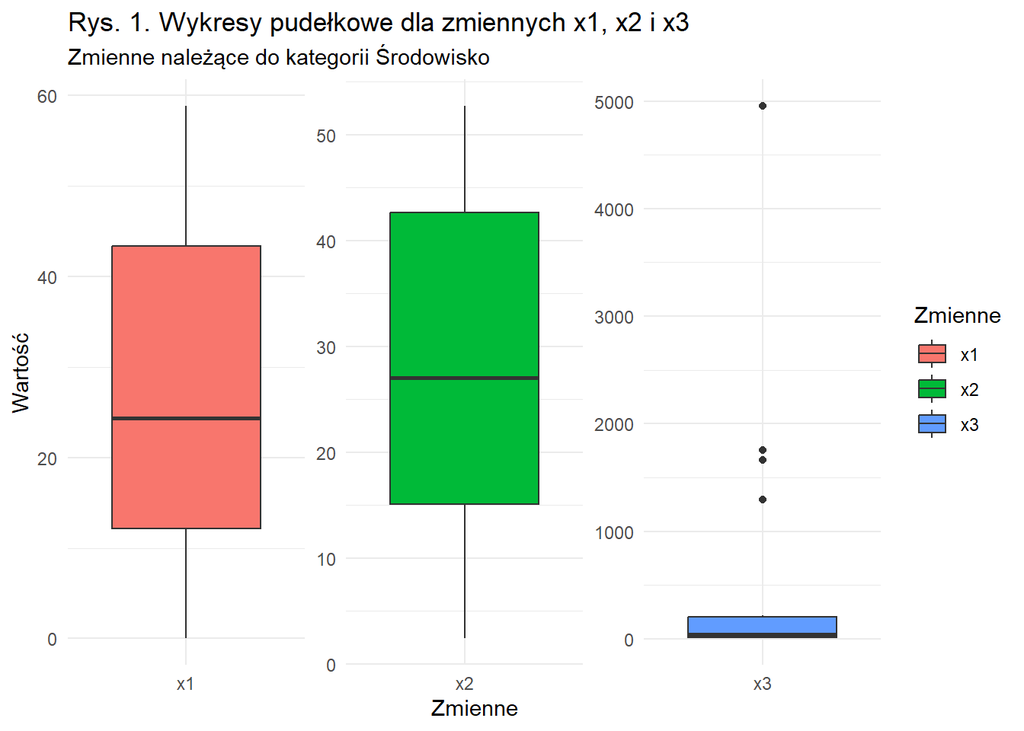

Dla zmiennej X$_3$, która mierzy emisję zanieczyszczeń gazowych, powiaty kwidzyński, Gdańsk, Gdynia oraz Słupsk wykazały znacznie wyższe wartości emisji, co czyni je zarówno wartościami odstającymi, jak i ekstremalnymi.

```
##       Powiat      x3 is.outlier is.extreme
## 1 kwidzyński 1290.65       TRUE       TRUE
## 2     Gdańsk 4952.20       TRUE       TRUE
## 3     Gdynia 1664.27       TRUE       TRUE
## 4     Słupsk 1755.05       TRUE       TRUE
```

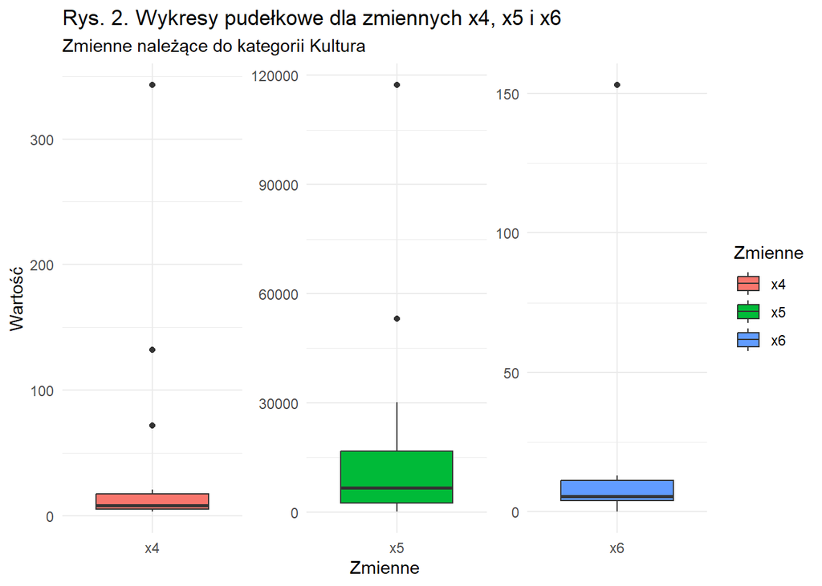

Dla zmiennej X$_4$ określającej liczba zabytków nieruchomych, powiaty Gdańsk, Słupsk i Sopot wykazują wartości odstające, we wszystkich tych powiatach wartości te są klasyfikowane również jako ekstremalne.

```
##   Powiat     x4 is.outlier is.extreme
## 1 Gdańsk  72.04       TRUE       TRUE
## 2 Słupsk 132.08       TRUE       TRUE
## 3  Sopot 342.86       TRUE       TRUE
```

Dla zmiennej X$_5$ opisującej zwiedzających muzea oraz oddziały, powiaty malborski i nowodworski wykazują wartości odstające, z czego w powiecie malborskim zidentyfikowano wartość ekstremalną, co sugeruje wyjątkowo wysoką liczbę odwiedzających w porównaniu z innymi regionami.

```
##        Powiat       x5 is.outlier is.extreme
## 1   malborski 117307.5       TRUE       TRUE
## 2 nowodworski  53161.8       TRUE      FALSE
```

Sopot wykazuje zarówno wartość odstającą, jak i ekstremalną dla liczby masowych imprez artystyczno-rozrywkowych, co sugeruje znacznie wyższą aktywność kulturalno-rozrywkową w tym powiecie.

```
##   Powiat  x6 is.outlier is.extreme
## 1  Sopot 153       TRUE       TRUE
```

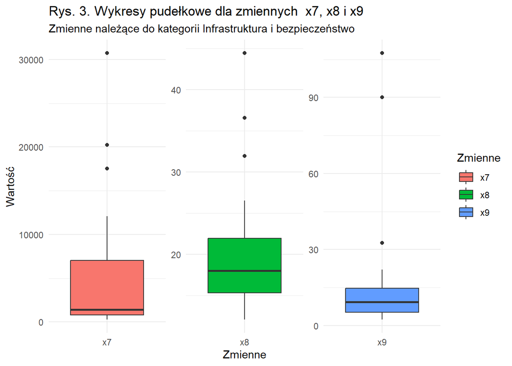

Dla zmiennej X$_7$ określającej udzielone noclegi, powiaty nowodworski, pucki i Sopot wykazują wartości odstające. W Sopocie odnotowano dodatkowo wartość ekstremalną, co wskazuje na wyjątkowo wysoki poziom turystyki w porównaniu do innych powiatów.

```
##        Powiat       x7 is.outlier is.extreme
## 1 nowodworski 20252.79       TRUE      FALSE
## 2       pucki 17550.88       TRUE      FALSE
## 3       Sopot 30724.37       TRUE       TRUE
```

Wysoka wartość przestępstw (X$_8$) w Sopocie może sugerować wyzwania związane z bezpieczeństwem w tym rejonie turystycznym. Pozostałe powiaty, mimo że również wykazują wartości odstające, nie osiągają poziomu ekstremalnego.

```
##     Powiat    x8 is.outlier is.extreme
## 1 kartuski 36.58       TRUE      FALSE
## 2   Gdańsk 31.97       TRUE      FALSE
## 3    Sopot 44.43       TRUE       TRUE
```

Dla zmiennej X$_9$ opisującej długość dróg rowerowych, wartości odstające zidentyfikowano dla Gdańska, Słupska i Sopotu. Powiaty Słupsk oraz Sopot charakteryzują się wartościami ekstremalnymi, wskazując na szczególnie rozbudowaną infrastrukturę rowerową, natomiast w Gdańsku wartość jest odstająca, ale nie ekstremalna.

```
##   Powiat     x9 is.outlier is.extreme
## 1 Gdańsk  32.65       TRUE      FALSE
## 2 Słupsk 107.45       TRUE       TRUE
## 3  Sopot  90.06       TRUE       TRUE
```

W celu zredukowania wpływu wartości skrajnych na wyniki analizy, zdecydowano się na przeprowadzenie winsoryzacji tj. zastąpieniu wartości odstających długością górnego wąsa obliczaną według wzoru: $\small {Q_3} + 1,5 \cdot {(Q_3 - Q_1)}$. Statystyki opisowe dla rozważanych zmiennych diagnostycznych po dokonaniu winsoryzacji przedstawiono w tabeli (Tab. 2).

Tabela 2. Statystyki opisowe zmiennych diagnostycznych

|  | Średnia | Mediana | Min | Max | Odchylenie standardowe | Współczynnik zmienności | Skośność | Kurtoza |
| --- | --- | --- | --- | --- | --- | --- | --- | --- |
| x1 | 27.810 | 24.350 | 0.00 | 58.800 | 16.845 | 60.572 | 0.256 | -1.193 |
| x2 | 28.090 | 27.050 | 2.40 | 52.700 | 16.365 | 58.259 | 0.033 | -1.515 |
| x3 | 145.994 | 41.255 | 2.05 | 495.219 | 191.242 | 130.993 | 1.036 | -0.646 |
| x4 | 13.346 | 8.270 | 3.30 | 35.786 | 11.001 | 82.423 | 1.079 | -0.212 |
| x5 | 11290.880 | 6627.800 | 32.90 | 38064.000 | 12401.884 | 109.840 | 1.088 | -0.313 |
| x6 | 7.256 | 5.500 | 0.00 | 22.125 | 5.319 | 73.296 | 0.999 | 0.611 |
| x7 | 4699.444 | 1412.185 | 257.77 | 16371.614 | 5928.858 | 126.161 | 1.102 | -0.499 |
| x8 | 20.049 | 18.010 | 12.07 | 31.949 | 6.204 | 30.946 | 0.828 | -0.605 |
| x9 | 12.110 | 9.240 | 2.31 | 29.042 | 8.821 | 72.841 | 0.861 | -0.629 |

W porządkowaniu liniowym kluczowym aspektem jest dobór zmiennych, które powinny charakteryzować się wysoką zmiennością oraz niską korelacją między sobą. Przyjmuje się, że współczynnik zmienności powinien wynosić co najmniej 10%. Wszystkie zmienne w rozważanym zbiorze danych spełniły wspomniane założenie. W związku z powyższym, nie dokonano wykluczania żadnej z nich.

Następnie przeprowadzono analizę korelacji pomiędzy zmiennymi. Nie stwierdzono występowania zjawiska współliniowości dla żadnej z rozważanych par zmiennych diagnostycznych. Wszystkie wartości współczynnika korelacji, wyznaczone metodą Spearmana, były niższe niż próg 90%, co wskazuje na brak silnej zależności korelacyjnej między zmiennymi.

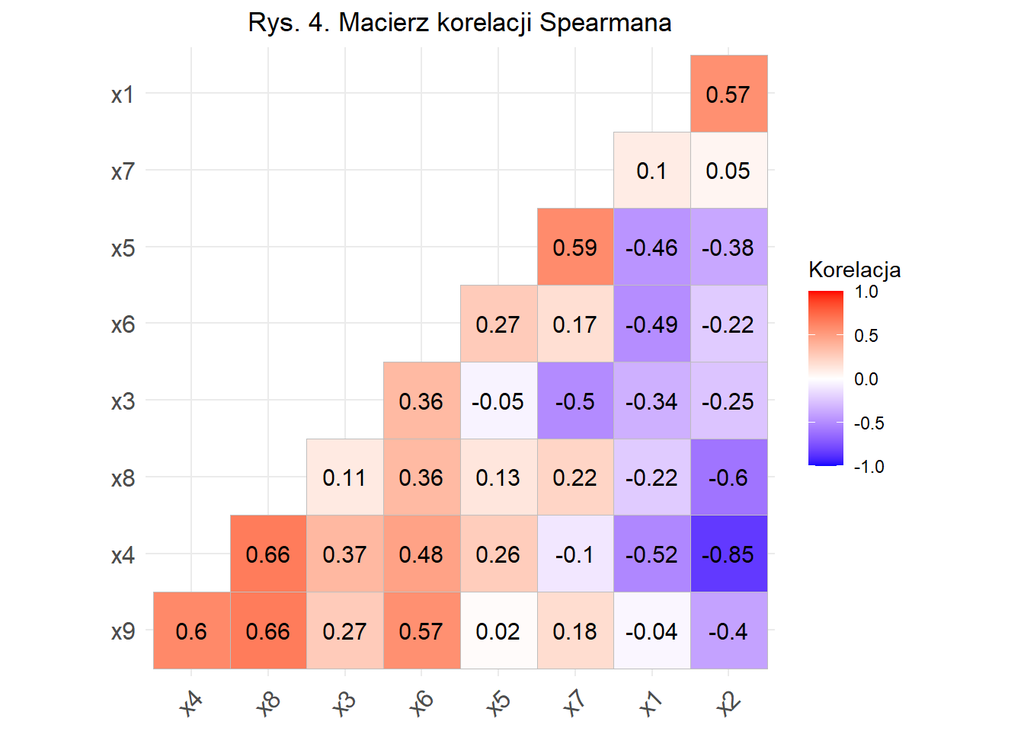

## 2. Porządkowanie liniowe

Porządkowanie liniowe umożliwia ustalenie rankingu obiektów względem przyjętego kryterium tzw. zmiennej syntetycznej, której wartość uzależniona jest od wartości cech charakteryzujących badane obiekty. Spośród metod porządkowania liniowego wyróżnia się metody wzorcowe oraz bezwzorcowe.

W niniejszej pracy zastosowane zostaną trzy metody porządkowania liniowego: Hellwiga, TOPSIS oraz standaryzowanych sum. Na zmienne diagnostyczne nałożony został system wag dobrany zgodnie z metodami eksperckimi oraz własnymi przekonaniami.

### 2.1. Metoda Hellwiga

Metoda Hellwiga jest jedną z najczęściej wykorzystywanych metod taksonomicznych. Jej koncepcja opiera się na uporządkowaniu obiektów w przestrzeni wielowymiarowej w oparciu o wyznaczony wskaźnik syntetyczny, który mierzy odległość obiektu od hipotetycznego wzorca, reprezentującego najbardziej korzystne wartości zmiennych diagnostycznych. Wadą wspomnianej metody jest możliwość przyjmowania wartości ujemnych przez obiekty znacząco oddalone od przyjętego wzorca. Zazwyczaj jednak wartości uzyskiwane w tej metodzie mieszczą się w zakresie od 0 do 1.

Pierwszym etapem wyznaczania miary syntetycznej w oparciu o algorytm Hellwiga jest przekształcenie wszystkich zmiennych diagnostycznych na stymulanty. Następnie w celu zapewnienia porównywalności badanych cech dokonuje się ich standaryzacji zgodnie ze wzorem:

$$\small z_{i j}=\frac{x_{i
j}-\bar{x}_j}{s_j}$$

gdzie $\bar{x}_j$, ${s_j}$ oznaczają odpowiednio średnią arytmetyczną oraz odchylenie standardowe dla zmiennej ${x_j}$.

Kolejno wyznaczana jest postać wzorca tzn. hipotetycznego obiektu o najkorzystniejszych zaobserwownanych wartościach zmiennych.

$$\small d_j^{+}=\max _{i=1 \ldots n} z_{i
j}$$

W kolejnym kroku wyznaczana jest odległość każdego obiektu od hipotetycznego wzorca. W przypadku niniejszego badania wykorzystano odległość euklidesową obliczaną według wzoru:

$$\scriptsize d_i=\sqrt{\sum\left(x_{i
j}-d_j^{+}\right)^2}$$

Ostatecznie dla każdego obiektu wyznaczany jest syntetyczny wskaźnik taksonomicznej „odległości” od przyjętego wzorca przy zastosowaniu poniższego wzoru:

$$\small s_i=1-\frac{d_{i
0}}{d_0}$$

gdzie $\small {d_0}$ oznacza krytyczną odległość danej jednostki od wzorca przyjmując $\small d_0=\bar{d}_i+2 \cdot s\left(d_i\right)$

Tabela 3. Ranking powiatów województwa pomorskiego pod względem atrakcyjności turystycznej uzyskany za pomocą metody Hellwiga

| Pozycja | Powiat | Wartość miernika | Pozycja | Powiat | Wartość miernika |
| --- | --- | --- | --- | --- | --- |
| 1 | Gdańsk | 0.579 | 11 | tczewski | 0.232 |
| 2 | Sopot | 0.560 | 12 | lęborski | 0.232 |
| 3 | malborski | 0.417 | 13 | sztumski | 0.230 |
| 4 | nowodworski | 0.390 | 14 | kartuski | 0.177 |
| 5 | Gdynia | 0.373 | 15 | gdański | 0.163 |
| 6 | pucki | 0.373 | 16 | starogardzki | 0.152 |
| 7 | Słupsk | 0.315 | 17 | wejherowski | 0.147 |
| 8 | kościerski | 0.265 | 18 | chojnicki | 0.137 |
| 9 | słupski | 0.239 | 19 | człuchowski | 0.130 |
| 10 | kwidzyński | 0.238 | 20 | bytowski | 0.117 |

W celu dokładniejszego zbadania przestrzennego zróżnicowania atrakcyjności turystycznej w powiatach oraz miastach na prawach powiatu w województwie pomorskim dokonano klasyfikacji obiektów z punktu widzenia osiągniętego poziomu badanego zjawiska. Zgodnie z zasadą jednego odchylenia od średniej dokonano podziału obiektów na cztery grupy:

- grupa I obejmuje powiaty o najwyższej atrakcyjności turystycznej:
  $$r > \bar{r} + s_r$$
- grupa II obejmuje powiaty o ponadprzeciętnym wskaźniku atrakcyjności turystycznej:
  $$\bar{r} < r \leq
  \bar{r}+s_r$$
- grupa III obejmuje powiaty o przeciętnym wskaźniku atrakcyjności turystycznej:
  $$\bar{r} - s_r < r \leq
  \bar{r}$$
- grupa IV obejmuje powiaty o niskim wskaźniku atrakcyjności turystycznej:
  $$r<\bar{r} - s_r$$

gdzie $\small r$ oznacza wartość wskaźnika syntetycznego, a $\small \bar{r}, s_r$ odpowiednio średnią arytmetyczną i odchylenie standardowe wartości danego wskaźnika syntetycznego.

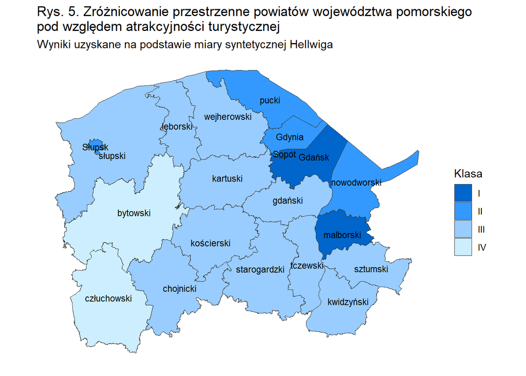

Analizując przestrzenne zróżnicowanie atrakcyjności turystycznej w województwie pomorskim, oparte na klasyfikacji wyników rankingu uzyskanych metodą Hellwiga zgodnie z zasadą jednego odchylenia standardowego od średniej (Rys. 5), można zauważyć, że powiaty o wysokim potencjale turystycznym zlokalizowane są w północno-wschodniej części regionu. W grupie o najwyższym poziomie atrakcyjności turystycznej znajdują się dwa duże miasta na prawach powiatu tj. Gdańsk, Sopot oraz powiat malborski. Większość powiatów charakteryzuje się przeciętnym poziomem atrakcyjności turystycznej. Najniższe wartości wskaźników odnotowano w powiatach bytowskim i człuchowskim, położonych w południowo-zachodniej części województwa.

### 2.2. Metoda TOPSIS

Alternatywną metodą wzorcową porządkowania liniowego umożliwiającą ustalenie rankingu obiektów, jest metoda TOPSIS. W odróżnieniu od metody Hellwiga, w technice tej odległości obiektów w przestrzeni wielowymiarowej są określane względem dwóch punktów odniesienia: wzorca oraz antywzorca.

Analogicznie jak w poprzedniej technice dokonywane jest przekształcenie wszystkich zmiennych diagnostycznych na stymulanty. Następnie w celu zapewnienia porównywalności badanych cech dokonywana jest ich normalizacja przy zastosowaniu przekształcenia ilorazowego zgodnie ze wzorem:

$$\small z_{i j}=\frac{x_{i j}}{\sqrt{\sum_{i=1}^m x_{i j}^2}}$$

Na tym etapie na znormalizowane wartości zostaje nałożony uprzednio ustalony system wag tj. $\small v_{i j}=w_j \cdot z_{i j}$. Następnie wyznaczane są wzorzec oraz antywzorzec:

$$\small a^{+}=\left(a_1^{+}, \ldots, a_n^{+}\right); \quad
a^{-}=\left(a_1^{-}, \ldots, a_n^{-}\right)$$
a także odległości od wzorca i antywzorca według wzorów:

$$\scriptsize d_i^{+}=\sqrt{\sum_{j=1}^n\left(v_{i j}-a_j^{+}\right)^2};
\quad d_i^{-}=\sqrt{\sum_{j=1}^n\left(v_{i j}-a_j^{-}\right)^2}$$
Na koniec wyznaczane są wartości zmiennej agregatowej $\small R_i$ należącej do przedziału $\small [0, 1]$ zgodnie z zamieszczonym niżej wzorem:

$$\scriptsize R_i=\frac{d_i^{-}}{d_i^{-}+d_i^{+}}$$

Tabela 4. Ranking powiatów województwa pomorskiego pod względem atrakcyjności turystycznej uzyskany za pomocą metody TOPSIS

| Pozycja | Powiat | Wartość miernika | Pozycja | Powiat | Wartość miernika |
| --- | --- | --- | --- | --- | --- |
| 1 | Gdańsk | 0.671 | 11 | chojnicki | 0.263 |
| 2 | Sopot | 0.630 | 12 | tczewski | 0.256 |
| 3 | nowodworski | 0.568 | 13 | kwidzyński | 0.245 |
| 4 | malborski | 0.540 | 14 | sztumski | 0.242 |
| 5 | pucki | 0.482 | 15 | kartuski | 0.228 |
| 6 | Słupsk | 0.468 | 16 | wejherowski | 0.223 |
| 7 | kościerski | 0.396 | 17 | starogardzki | 0.215 |
| 8 | Gdynia | 0.392 | 18 | gdański | 0.215 |
| 9 | słupski | 0.325 | 19 | człuchowski | 0.212 |
| 10 | lęborski | 0.297 | 20 | bytowski | 0.207 |

Analogicznie jak w przypadku miary syntetycznej Hellwiga dokonano podziału powiatów województwa pomorskiego pod względem atrakcyjności turystycznej. Wyniki przeprowadzonej klasyfikacji przedstawiono na rysunku poniżej (Rys.6).

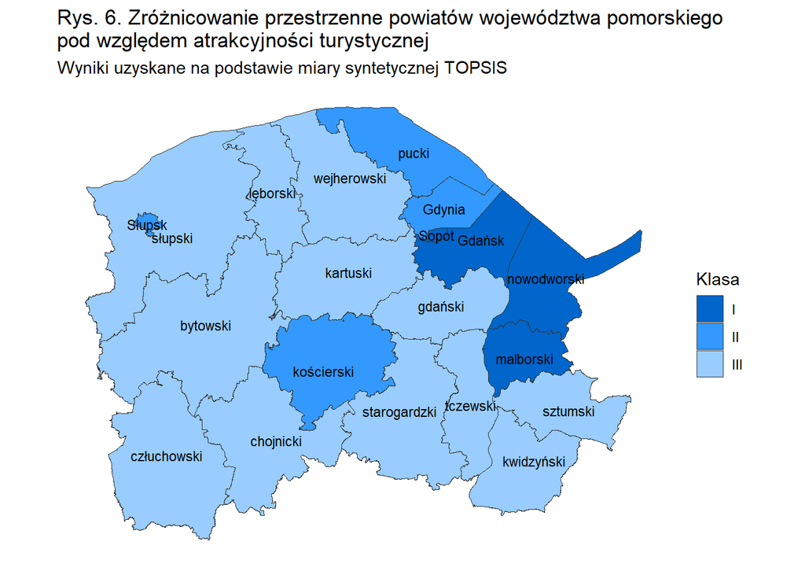

Klasyfikacja powiatów województwa pomorskiego na podstawie wyników uzyskanych metodą TOPSIS wskazuje, że najwyższy potencjał turystyczny charakteryzuje przede wszystkim powiaty nadmorskie (zob. Rys. 6). Wyjątek stanowi powiat kościerski, zlokalizowany w centralnej części województwa pomorskiego, który również wyróżnia się ponadprzeciętnym wskaźnikiem badanego zjawiska. Dominującą grupę stanowią powiaty o przeciętnym poziomie atrakcyjności turystycznej. Żaden z powiatów nie został sklasyfikowany w grupie o najniższym potencjale pod względem turystyki.

### 2.3. Metoda standaryzowanych sum

Jedną z prostych i powszechnie stosowanych technik porządkowania obiektów w grupie metod wskaźnika syntetycznego jest metoda standaryzowanych sum. Pożądanym działaniem przed zastosowaniem metod bezwzorcowych jest zamiana wszystkich cech na stymulanty.

Pierwszą czynnością jest standaryzacja zmiennych, która zapewnia porównywalność wszystkich cech. W kolejnym kroku dokonywane jest sumowanie wartości każdej zmiennej. Jeżeli zdecydowano się na zastosowanie systemu wag pozwalającego na zróżnicowanie znaczenia zmiennych wykorzystuje się wzór:

$$\small s_i=\sum_{j=1}^m w_i z_{i j}, \quad gdzie\quad \sum_{j=1}^m
w_j=1, \quad w_j \geq 0$$

Dla wyznaczonego wskaźnik można zastosować postępowanie normalizujące w celu ułatwienia interpretacji wyników. Normalizację wartości miary syntetycznej, tak aby przyjmowała ona wartości w przedziale [0, 1] można osiągnać poprzez zastosowanie wzoru:

$$\small s_i=\frac{s_i-\min \left(s_i\right)}{\max \left\{s_i-\min
\left(s_i\right)\right\}}$$

Tabela 5. Ranking powiatów województwa pomorskiego pod względem atrakcyjności turystycznej uzyskany za pomocą metody standaryzowanych sum

| Pozycja | Powiat | Wartość miernika | Pozycja | Powiat | Wartość miernika |
| --- | --- | --- | --- | --- | --- |
| 1 | Sopot | 1.000 | 11 | chojnicki | 0.203 |
| 2 | Gdańsk | 0.788 | 12 | wejherowski | 0.080 |
| 3 | pucki | 0.559 | 13 | kartuski | 0.078 |
| 4 | nowodworski | 0.526 | 14 | kwidzyński | 0.074 |
| 5 | malborski | 0.458 | 15 | starogardzki | 0.050 |
| 6 | Słupsk | 0.388 | 16 | sztumski | 0.032 |
| 7 | kościerski | 0.366 | 17 | gdański | 0.022 |
| 8 | Gdynia | 0.298 | 18 | człuchowski | 0.007 |
| 9 | lęborski | 0.223 | 19 | tczewski | 0.002 |
| 10 | słupski | 0.220 | 20 | bytowski | 0.000 |

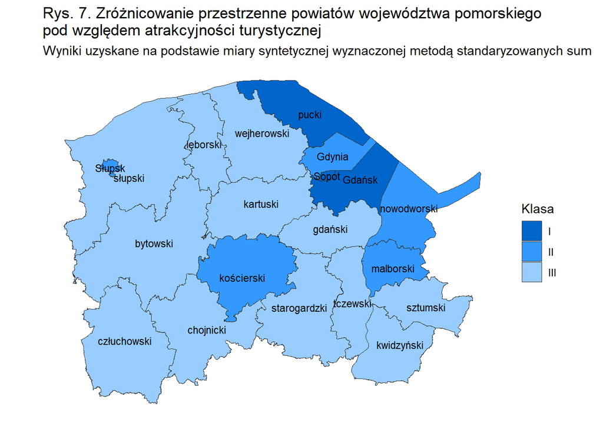

Wyniki klasyfikacji powiatów województwa pomorskiego, przeprowadzonej na podstawie wartości miary syntetycznej uzyskanej metodą sum standaryzowanych, wskazują na znaczną przewagę powiatów nadmorskich pod względem atrakcyjnosci turystycznej (zob. Rys. 7). Wyjątek stanowi powiat kościerski, który mimo centralnej lokalizacji w regionie, osiągnął ponadprzeciętną wartość badanego wskaźnika. Większość powiatów należy do grupy III, co wskazuje na ich przeciętny poziom atrakcyjności turystycznej.

### 2.4. Porównanie wyników porządkowania liniowego

W poprzednim punkcie przedstawiono szczegółowe rankingi powiatów województwa pomorskiego w kontekście ich atrakcyjności turystycznej. Wyniki te zostały uzyskane poprzez zastosowanie trzech metod porządkowania liniowego: metody Hellwiga, TOPSIS oraz standaryzowanych sum. Każda z tych metod pozwoliła na obiektywne i systematyczne ocenienie poziomu atrakcyjności turystycznej poszczególnych jednostek administracyjnych.

W poniższej tabeli przedstawiono zestawienie uzyskanych rankingów powiatów wynikających z zastosowania trzech wyżej wymienionych metod porządkowania liniowego. Porównanie rankingów umożliwia ocenę stabilności wyników oraz identyfikację ewentualnych różnic w klasyfikacji poszczególnych powiatów w zależności od zastosowanej metody.

Tabela 6. Ranking powiatów województwa pomorskiego pod względem atrakcyjności turystycznej uzyskany za pomocą metod: Hellwiga, TOPSIS oraz standaryzowanych sum

| Powiat | Hellwig | TOPSIS | Sumy | Powiat | Hellwig | TOPSIS | Sumy |
| --- | --- | --- | --- | --- | --- | --- | --- |
| Gdańsk | 1 | 1 | 2 | tczewski | 11 | 12 | 19 |
| Sopot | 2 | 2 | 1 | lęborski | 12 | 10 | 9 |
| malborski | 3 | 4 | 5 | sztumski | 13 | 14 | 16 |
| nowodworski | 4 | 3 | 4 | kartuski | 14 | 15 | 14 |
| Gdynia | 5 | 8 | 8 | gdański | 15 | 18 | 17 |
| pucki | 6 | 5 | 3 | starogardzki | 16 | 17 | 15 |
| Słupsk | 7 | 6 | 6 | wejherowski | 17 | 16 | 12 |
| kościerski | 8 | 7 | 7 | chojnicki | 18 | 11 | 11 |
| słupski | 9 | 9 | 10 | człuchowski | 19 | 19 | 18 |
| kwidzyński | 10 | 13 | 13 | bytowski | 20 | 20 | 20 |

Z analizy przedstawionej w tabeli 6 wynika, że w 2023 roku czołowe pozycje w rankingach atrakcyjności turystycznej niezmiennie zajmują miasta na prawach powiatu, takie jak Gdańsk i Sopot. Stabilność ich pozycji wskazuje na konsekwentnie wysokie walory turystyczne tych jednostek, niezależnie od zastosowanej metody porządkowania liniowego. Podobną stabilność obserwuje się na końcu rankingu, gdzie powiat bytowski zajmuje niezmienną 20. pozycję niezależnie od zastosowanej metody, podczas gdy powiat człuchowski wykazuje drobne wahania w swojej pozycji w rankingu opracowanym przy użyciu techniki bezwzorcowej. W przypadku pozostałych powiatów dostrzega się większe zróżnicowanie w klasyfikacji. Przykładem jest Gdynia, która według metody Hellwiga zajmuje 5. miejsce, natomiast w rankingach opartych na metodzie TOPSIS oraz sum standaryzowanych spada na 8. pozycję.

W celu dokładniejszej oceny zgodności porządkowania badanych obiektów między poszczególnymi rankingami, obliczono współczynniki tau Kendalla. Na podstawie danych przedstawionych w tabeli 7 można stwierdzić, że największa stabilność występuje między wynikami rankingu uzyskanymi z wykorzystaniem metody TOPSIS oraz metody standaryzowanych sum.

Tabela 7. Współczynniki korelacji rangowej τ-Kendalla dla różnych technik porządkowania liniowego

| Metoda | Hellwig | TOPSIS | Sumy |
| --- | --- | --- | --- |
| Hellwig | 1 | 0.821 | 0.674 |
| TOPSIS | 0.821 | 1 | 0.832 |
| Standaryzowane sumy | 0.674 | 0.832 | 1 |

Po przeprowadzonej analizie stabilności wyników porządkowania z użyciem współczynnika τ-Kendalla, kolejnym etapem interpretacji było porównanie rezultatów grupowania powiatów województwa pomorskiego pod względem ich atrakcyjności turystycznej. W Tabeli 8 zaprezentowano zbiorcze zestawienie wyników przestrzennego zróżnicowania powiatów województwa pomorskiego.

Tabela 8. Zestawienie wyników grupowania powiatów województwa pomorskiego pod względem atrakcyjności turystycznej

| Grupy | Metoda Hellwiga | Metoda TOPSIS | Metoda standaryzowanych sum |
| --- | --- | --- | --- |
| I | **Gdańsk**, **Sopot**, malborski | **Gdańsk**, **Sopot**, nowodworski, malborski | **Sopot**, **Gdańsk**, pucki |
| II | nowodworski, **Gdynia**, pucki, **Słupsk** | pucki, **Słupsk**, kościerski, **Gdynia** | nowodworski, malborski, **Słupsk**, kościerski, **Gdynia** |
| III | kościerski, **słupski**, **kwidzyński**, **tczewski**, **lęborski**, **sztumski**, **kartuski**, **gdański**, **starogardzki**, **wejherowski**, **chojnicki** | **słupski**, **lęborski**, **chojnicki**, **tczewski**, **kwidzyński**, **sztumski**, **kartuski**, **wejherowski**, **starogardzki**, **gdański**, człuchowski, bytowski | **lęborski**, **słupski**, **chojnicki**, **wejherowski**, **kartuski**, **kwidzyński**, **starogardzki**, **sztumski**, **gdański**, człuchowski, **tczewski**, bytowski |
| IV | człuchowski, bytowski |  |  |

We wszystkich rankingach, do jednostek o najwyższej atrakcyjności turystycznej należą miasta Gdańsk i Sopot, a w przypadku metod wzorcowych również powiat malborski. Niezależnie od wybranej metody, miasta Gdynia i Słupsk są klasyfikowane do grupy powiatów o ponadprzeciętnej atrakcyjności turystycznej. Wszystkie wymienione jednostki charakteryzujące się wysokim potencjałem turystycznym znajdują się w północnej części województwa pomorskiego.

Należy zauważyć, że grupa IV w zestawieniu atrakcyjności turystycznej powiatów województwa pomorskiego występuje wyłącznie w wynikach uzyskanych metodą Hellwiga. Należą do niej powiaty człuchowski i bytowski położone w południowo-zachodniej części regionu. W pozostałych metodach wspomniane powiaty zostały zaklasyfikowane do grupy o przeciętnym potencjale turystycznym.

[figure not shown]

W przypadku powiatów bytowskiego oraz człuchowskiego kluczowymi czynnikami wpływającymi na niską atrakcyjność turystyczną tych jednostek administracyjnych są wysokie wartości zmiennych związanych z emisją zanieczyszczeń gazowych (X$_3$) oraz zjawiskiem przestępczości (X$_8$). Ponadto, wspomniane powiaty charakteryzują się niskimi wartościami walorów kulturowych oraz ograniczonymi udogodnieniami turystycznymi, co znacząco hamuje ich potencjał w zakresie przyciągania turystów. Pomimo występowania w tych regionach licznych zalesionych obszarów (X$_2$), które mogłyby stanowić atut w kontekście turystyki przyrodniczej, brak odpowiedniej infrastruktury turystycznej oraz skutecznej promocji kulturalnej sprawia, że nie są one postrzegane jako atrakcyjne lokalizacje turystyczne.

## 3. Analiza skupień

Analiza skupień, określana również jako analiza klastrowa, to zestaw metod statystycznych służących do wielowymiarowej analizy danych, których celem jest segmentacja danych w taki sposób, aby wyodrębnić jednorodne grupy obiektów w badanej populacji. Proces ten polega na podziale zbioru danych na grupy, w których elementy cechują się jak największym podobieństwem, przy jednoczesnym zachowaniu wyraźnych różnic w stosunku do obiektów należących do innych grup. Analiza skupień obejmuje różnorodne algorytmy, które można podzielić na dwie główne kategorie: metody hierarchiczne oraz metody podziałowe (niehierarchiczne). Kluczową różnicą między tymi algorytmami jest fakt, że w metodach podziałowych konieczne jest wcześniejsze określenie liczby skupień.

Weryfikacji wstępnych warunków dotyczących doboru zmiennych w analizie skupień dokonano przed przystąpieniem do procesu porządkowania liniowego. Po szczegółowej analizie danych stwierdzono, że wszystkie wymagane kryteria zostały spełnione.

### 3.1. Grupowanie hierarchiczne

Grupowanie hierarchiczne polega na tworzeniu hierarchii skupień, rozpoczynając od pojedynczych obiektów, które są łączone w coraz większe grupy na podstawie wybranej metryki odległości. Proces ten trwa, aż wszystkie obiekty zostaną połączone w jeden klaster. Wynik analizy skupień przeprowadzonej z wykorzystaniem metody hierarchicznej przedstawia się najczęściej przy pomocy dendogramu.

Dla analizowanych danych zastosowano hierarchiczne grupowanie z wykorzystaniem metody łączenia Warda. Wspomniana metoda opiera się na analizie wariancji, minimalizując na każdym etapie wzrost łącznej sumy kwadratów odchyleń wszystkich cech obiektów od średnich w danym skupieniu. Jako miarę odległości przyjęto metrykę euklidesową, obliczaną według wzoru:
$$\scriptsize d(x, y)
=\sqrt{\sum\left(x_{i}-y_{i}\right)^2}$$
Przed przystąpieniem do algorytmu dokonano standaryzacji danych, aby zapewnić porównywalność wyników. Wyniki grupowania przedstawiono na poniższym dendrogramie.

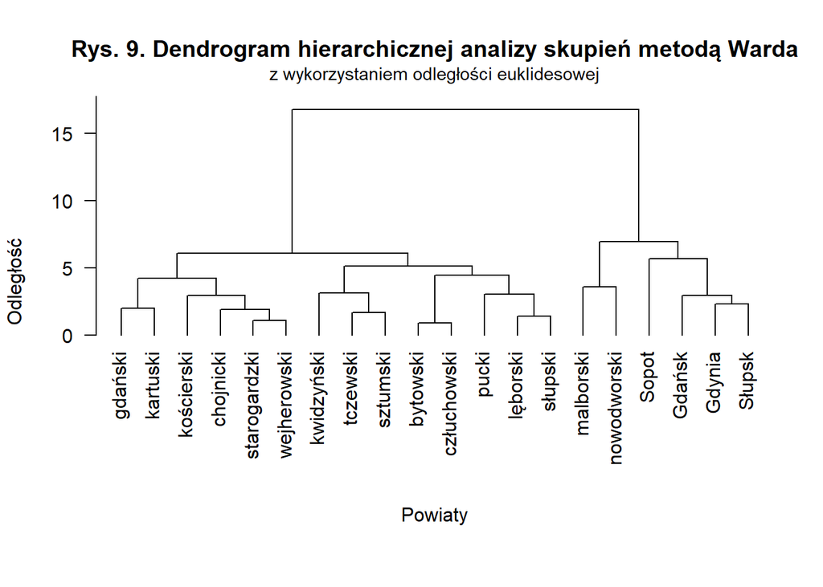

Jak można zauważyć, utworzone skupienia charakteryzują się zbliżoną liczbą obiektów, a także nie wykazują skłonności do tworzenia łańcuchowych połączeń. Szczególną uwagę należy zwrócić na fakt, iż powiaty bytowski i człuchowski zostały połączone jako pierwsze. Wysokie podobieństwo tych jednostek zostało również dostrzeżone na wykresie radarowym (zob. Rys. 8), podczas analizy wyników uzyskanych z zastosowaniem metod porządkowania liniowego.

Kluczowym aspektem analizy skupień jest wyznaczenie punktu odcięcia dendrogramu, co umożliwia określenie liczby skupień w analizowanym badaniu. W przeprowadzonym badaniu miejsce podziału dendrogramu ustalono przy zastosowaniu trzech metod. Pierwszy sposób wykorzystuje regułę R. Mojeny opisaną wzorem:
$$\small {d_{h+1}}
> \bar d + k \cdot S(d)$$
gdzie $\small \bar d$ oznacza średnią arytmetyczną długości wiązań, $\small S(d)$ odchylenie standardowe długości wiązań, a $\small k$ to stała, której wartość według R. Mojeny powinna zawierać się w przedziale $\small [2.5, 3.5]$. W praktyce najczęściej przyjmuje się wartość parametru $\small k = 1.25$ ustaloną na podstawie badań Milligan i Cooper (1985). Przyjmując $\small k = 1.25$ odcięcie dendrogramu następuje dla $\small {d_{h+1}} > 8.42$, co sugeruje podział zbioru na dwa skupienia. Wyniki uzyskanego podziału zamieszczono na rysunku poniżej.

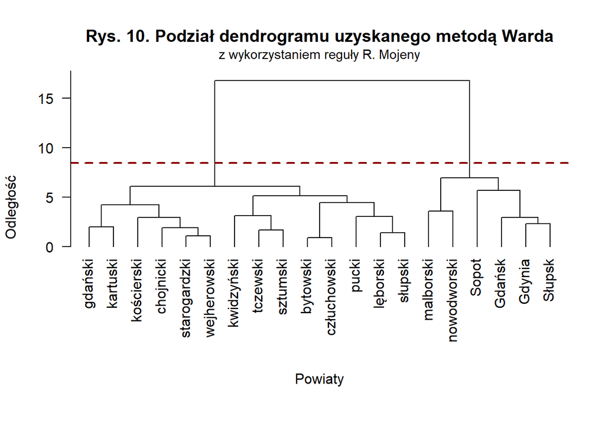

Drugi sposób polegał na analizie wykresu odległości wiązań w odniesieniu do kolejnych etapów wiązania. Po zidentyfikowaniu największego przyrostu odległości dokonywane jest odcięcie, które dzieli zbiór na klasy.

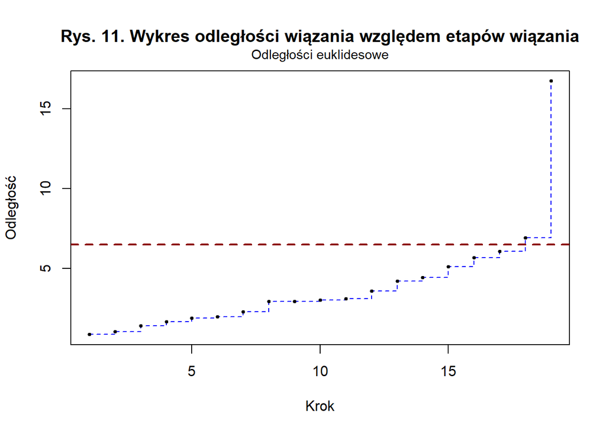

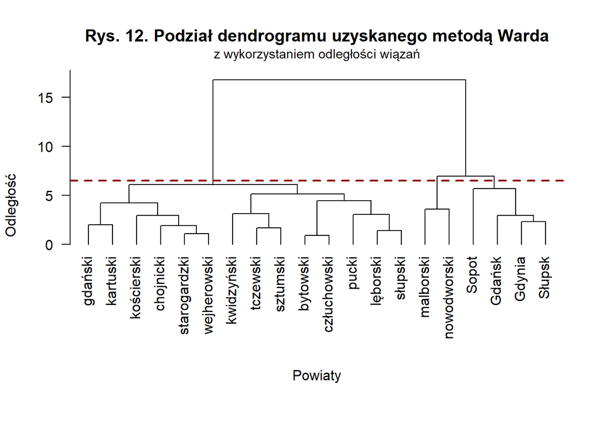

Na zakończenie analizy przeprowadzono ocenę jakości klasyfikacji przy użyciu czterech indeksów: G1, G2, G3 oraz Silhouette, które służą do określenia optymalnej liczby klas w badanym zbiorze danych. W przypadku indeksów G1, G2 oraz indeksu sylwetkowego celem było zidentyfikowanie wartości maksymalnej, z kolei dla indeksu G3 wartości najmniejszej.

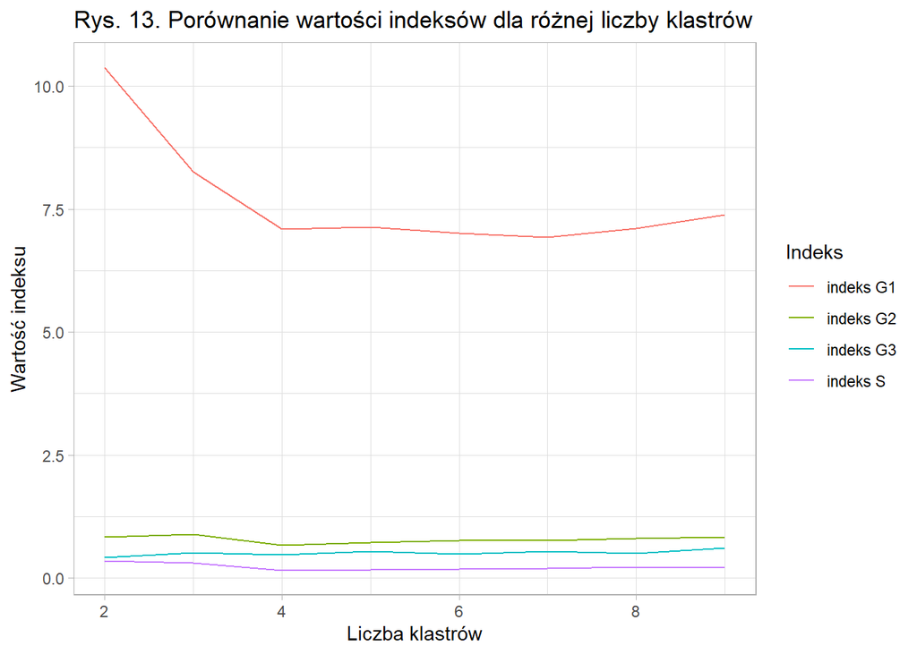

W związku z trudnościami w identyfikacji wartości ekstremalnych na przedstawionej wizualizacji, dokonano zestawienia odpowiednich wartości, które zamieszczono w tabeli poniżej (zob. Tab. 9). Rezultaty uzyskane przy pomocy indeksów jakości klasyfikacji okazały się wyjątkowo zgodne. Spośród czterech rozważanych indeksów, trzy wskazały jako odpowiedni podział obiektów na dwa skupienia.

Tabela 9. Zestawienie wyników indeksów oceny jakości klasyfikacji służące wyborowi liczby klas

| Indeks | Wartość |
| --- | --- |
| G1 | 2 |
| G2 | 3 |
| G3 | 2 |
| S | 2 |

Optymalne rozwiązanie w analizie skupień przy zastosowaniu metody Warda wskazuje na podział obiektów na dwa skupienia. Jednakże, ze względu na częste wskazania kryteriów sugerujących podział na trzy klastry, a także biorąc pod uwagę ogólny podział zmiennych na trzy główne kategorie (środowisko, kultura, infrastruktura i bezpieczeństwo), zdecydowano się na przeprowadzenie analizy dla obu opcji — dwóch oraz trzech klastrów. Celem tego podejścia jest wybór bardziej adekwatnego podziału, który najlepiej odzwierciedli strukturę danych.

W dalszej części pracy przedstawiono wartości średnie oraz odchylenia standardowe dla poszczególnych grup w obu wariantach podziału, co pozwala na bardziej szczegółową ocenę oraz porównanie wyników tych dwóch alternatywnych klasyfikacji.

Tabela 10. Statystyki opisowe grup obiektów w podziale na dwa skupienia

[output not shown]

Skupienie 1, obejmujące 14 obiektów, cechuje się relatywnie niższymi walorami kulturowymi oraz ograniczoną dostępnością infrastruktury rowerowej. Powiaty należące do tej grupy posiadają niższy potencjał dziedzictwa kulturowego, co znajduje odzwierciedlenie w ograniczonej liczbie zabytków, mniejszym zainteresowaniu zwiedzających muzeami oraz niższym poziomie uczestnictwa w wydarzeniach artystyczno-rozrywkowych. Z drugiej strony, wyróżniają się pozytywnie pod względem środowiskowym, ze względu na wysoki udział obszarów chronionych oraz znaczną powierzchnię lasów. Mimo korzystnych walorów przyrodniczych, w powiatach tych zauważa się również występowanie destymulujących czynników, takich jak stosunkowo wysoka emisja zanieczyszczeń gazowych oraz podwyższony poziom przestępczości.

Skupienie 2 obejmuje regiony o wyraźnie gorszej kondycji środowiskowej, co uwidacznia się w ujemnych średnich wartościach zmiennych dotyczących udziału obszarów chronionych oraz lesistości. W porównaniu do skupienia 1, powiaty te odznaczają się wyraźnie wyższymi walorami kulturowymi, co potwierdzają znaczące liczby zabytków, odwiedzających muzea oraz organizowanych wydarzeń artystyczno-rozrywkowych. Te dane wskazują na istotne znaczenie ośrodków kultury i rozrywki w tych regionach. Powiaty należące do tej grupy są również lepiej rozwinięte pod względem infrastruktury rowerowej, co sprzyja aktywnościom rekreacyjnym. Zauważalna jest również stosunkowo niewielka emisja zanieczyszczeń gazowych oraz ograniczony poziom przestępczości. Należy jednak podkreślić, że w obrębie tego klastra występuje znaczna różnorodność wymienionych cech.

Tabela 11. Statystyki opisowe grup obiektów w podziale na trzy skupienia

| Zmienne | Skupienie 1 (n = 14) Średnia arytmetyczna | Skupienie 1 (n = 14) Odchylenie standardowe | Skupienie 2 (n = 2) Średnia arytmetyczna | Skupienie 2 (n = 2) Odchylenie standardowe | Skupienie 3 (n = 4) Średnia arytmetyczna | Skupienie 3 (n = 4) Odchylenie standardowe |
| --- | --- | --- | --- | --- | --- | --- |
| x1 | 0.392 | 0.899 | -0.873 | 0.403 | -0.937 | 0.617 |
| x2 | 0.407 | 0.834 | -1.463 | 0.151 | -0.693 | 0.689 |
| x3 | 0.305 | 0.707 | 0.233 | 0.726 | -1.184 | 1.284 |
| x4 | -0.513 | 0.401 | 0.277 | 0.573 | 1.657 | 0.766 |
| x5 | -0.373 | 0.606 | 2.159 | 0.000 | 0.226 | 0.957 |
| x6 | -0.397 | 0.625 | -0.048 | 1.064 | 1.415 | 0.925 |
| x7 | -0.170 | 0.861 | 0.666 | 1.842 | 0.261 | 1.210 |
| x8 | 0.381 | 0.785 | -0.121 | 0.656 | -1.274 | 0.816 |
| x9 | -0.440 | 0.500 | -0.370 | 0.658 | 1.723 | 0.392 |

Dla podziału zbioru obiektów na trzy klastry, powiaty należące do pierwszego skupienia wyróżniają się znaczną powierzchnią obszarów prawnie chronionych oraz wysokim stopniem zalesienia. Jednakże, nie wszystkie powiaty w tej grupie wykazują te właściwości w równym stopniu. Grupa ta wyróżnia się także stosunkowo niskim poziomem zasobów dziedzictwa kulturowego, co można zaobserwować poprzez ograniczoną liczbę zabytków, typową dla większości powiatów. Dodatkowo, słabiej rozwinięta baza noclegowa świadczy o niższym poziomie infrastruktury turystycznej, przy czym występują tu pewne zróżnicowania pomiędzy poszczególnymi powiatami. Podobnie, infrastruktura rowerowa jest na ogół słabo rozwinięta i niejednorodna w całej grupie.

Skupienie 2 obejmuje jedynie dwa powiaty, które wyróżniają się znacząco na tle innych jednostek terytorialnych pod względem liczby zwiedzających muzea. Jednostki te charakteryzują się również niskim udziałem obszarów prawnie chronionych oraz stosunkowo ograniczonym zalesieniem. W zakresie infrastruktury turystycznej, mierzonej liczbą udzielonych noclegów, powiaty te osiągają wyniki wyższe niż w innych skupieniach, jednakże wykazują większe zróżnicowanie w tej kwestii w obrębie samej grupy.

Podsumowując przeprowadzone analizy, podział na trzy klastry wydaje się bardziej uzasadniony, gdyż lepiej odzwierciedla różnorodność cech powiatów. W ramach drugiego oraz trzeciego skupienia występują istotne różnice w wartościach zmiennych, co wskazuje na odmienne walory kulturowe i infrastrukturalne w analizowanych regionach. Ponadto, zróżnicowanie w obrębie uzyskanych skupień jest stosunkowo mniejsze, co sugeruje, że cechy te stają się charakterystyczne dla całego klastra.

### 3.2. Grupowanie podziałowe

Grupowanie podziałowe polega na podziale zbioru obiektów na wcześniej określoną liczbę rozłącznych grup. Charakterystyczną cechą metod grupowania podziałowego jest tworzenie ostatecznych skupień tzn. takich, które nie zawierają innych skupień. Najbardziej znaną metodą w tej kategorii jest algorytm k-średnich. Polega on na wstępnym podzieleniu zbioru obiektów na z góry założoną liczbę klas. Następnie dokonuje się optymalizacji uzyskanego podziału poprzez przenoszenie niektórych elementów do innych klas, aby zminimalizować wariancję wewnętrzną w obrębie każdej z nich. Celem jest zatem zapewnienie największego podobieństwa elementów dla każdej z grup, przy jednoczesnej maksymalnej różnicy pomiędzy samymi grupami.

W kontekście algorytmu k-średnich, kluczowe jest określenie liczby skupień, na które mają zostać podzielone dane. Wybór optymalnej liczby skupień może być wspomagany przez zastosowanie różnych metod statystycznych. W niniejszej analizie skoncentrowano się na wykresie osypiska, który ze względu na swoją prostotę cieszy się powszechnym zastosowaniem. Metoda ta ocenia stosunek wyjaśnionej wariancji do całkowitej wariancji jako funkcję liczby skupień. Proces rozpoczyna się od jednego klastra, a wartość ta szybko rośnie, aż do momentu, w którym przyrost ten zaczyna się spowalniać lub zatrzymywać. Wykres ilustrujący wspomniane zmiany przyjmuje kształt przypominający łokieć, co pozwala na identyfikację punktu optymalnego dla liczby skupień.

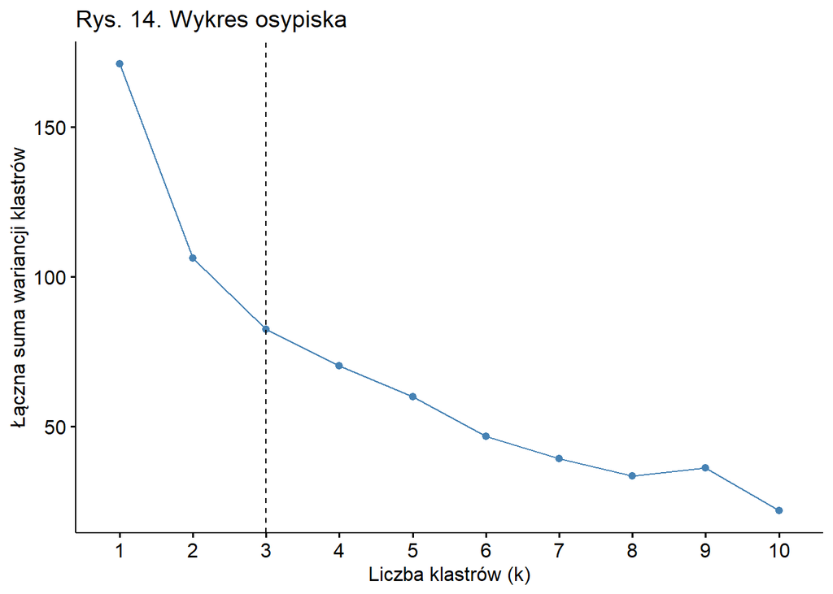

Według powyższego wykresu optymalnym rozwiązaniem jest podział powiatu na trzy skupienia. Wyniki uzyskanego podziału zamieszczono na poniższej wizualizacji.

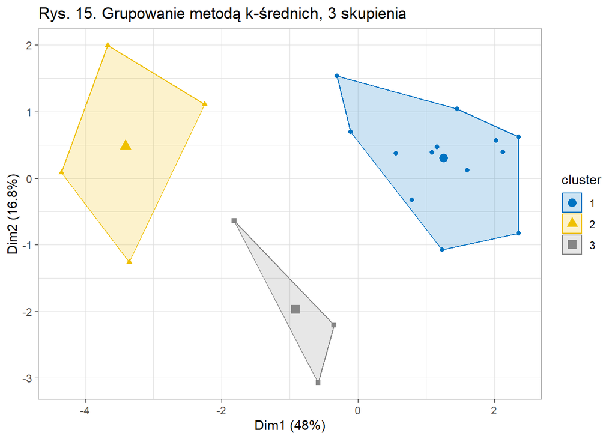

Ostatnim etapem analizy jest odpowiednia charakterystyka uzyskanych w wyniku podziału klastrów. W tym celu wyznaczone zostały średnia oraz odchylenie standardowe w ramach każdej grupy (zob. Tab. 12).

Tabela 12. Statystyki opisowe grup obiektów w podziale na trzy skupienia

| Zmienne | Skupienie 1 (n = 13) Średnia arytmetyczna | Skupienie 1 (n = 13) Odchylenie standardowe | Skupienie 2 (n = 4) Średnia arytmetyczna | Skupienie 2 (n = 4) Odchylenie standardowe | Skupienie 3 (n = 3) Średnia arytmetyczna | Skupienie 3 (n = 3) Odchylenie standardowe |
| --- | --- | --- | --- | --- | --- | --- |
| x1 | 0.398 | 0.935 | -0.937 | 0.617 | -0.476 | 0.746 |
| x2 | 0.474 | 0.827 | -0.693 | 0.689 | -1.130 | 0.587 |
| x3 | 0.273 | 0.726 | -1.184 | 1.284 | 0.395 | 0.585 |
| x4 | -0.513 | 0.418 | 1.657 | 0.766 | 0.014 | 0.609 |
| x5 | -0.464 | 0.522 | 0.226 | 0.957 | 1.710 | 0.777 |
| x6 | -0.511 | 0.477 | 1.415 | 0.925 | 0.328 | 0.995 |
| x7 | -0.334 | 0.627 | 0.261 | 1.210 | 1.100 | 1.504 |
| x8 | 0.372 | 0.816 | -1.274 | 0.816 | 0.086 | 0.586 |
| x9 | -0.496 | 0.472 | 1.723 | 0.392 | -0.150 | 0.602 |

Powiaty należące do pierwszego skupienia charakteryzują się relatywnie niskim poziomem walorów kulturowych, co przejawia się w ograniczonej liczbie zabytków oraz niskiej aktywności kulturalnej, mierzonej liczbą odwiedzających muzea, a także organizowanych wydarzeń artystyczno-rozrywkowych. Grupa ta wyróżnia się również słabo rozwiniętą infrastrukturą rowerową. Pod względem sytuacji środowiskowej, powiaty te wypadają korzystnie, jednakże występuje w tej kwestii znaczne zróżnicowanie wewnątrz grupy.

Skupienie 3 liczące trzy powiaty wyróżnia się przede wszystkim niekorzystnymi warunkami środowiskowymi, w tym stosunkowo wysokim poziomem emisji zanieczyszczeń. Aktywność kulturalna w tej grupie jest na umiarkowanym poziomie, choć widoczne jest znaczące zainteresowanie muzeami. Ponadto, w powiatach tego skupienia widoczna jest słabiej rozwinięta infrastruktura rowerowa.

### 3.3. Porównanie wyników grupowania

[figure not shown]

## 4. Podsumowanie

Zastosowanie analizy skupień oraz metod porządkowania liniowego w badaniu atrakcyjności turystycznej województwa pomorskiego przynosi zbieżne wyniki, wskazując na wysoką zgodność obu podejść. Powiaty, które tworzą mniejsze skupienia, zajmują zbliżone pozycje w rankingach uzyskanych dzięki technikom porządkowania liniowego, co sugeruje ich podobieństwo pod względem atrakcyjności turystycznej. Wyniki analizy wskazują, że powiaty zlokalizowane w północno-wschodniej części województwa pomorskiego posiadają wyższy potencjał turystyczny ze względu na bogactwo walorów kulturowych oraz dobrze rozwiniętą infrastrukturę rowerową, co sprzyja aktywności rekreacyjnej.